# Project №1

# 1 Getting data from different files

The function clam_old() takes an absolute path to the file as an argument. Please enter it into 1-proj.rmd.

```r
file_path <- "C:/Users/Катюша/Desktop/учеба/r-stat/Data"
clam_old(file_path)
str(working_df)
```

```
## 'data.frame':    4177 obs. of  9 variables:
##  $ Rings         : chr  "18" "14" "8" "12" ...
##  $ Sex           : chr  "2" "3" "1" "1" ...
##  $ Length        : chr  "0.575" "0.385" "0.475" "0.665" ...
##  $ Diameter      : num  0.45 0.305 0.37 0.525 0.12 0.16 0.565 0.43 0.175 0.3 ...
##  $ Height        : num  0.17 0.095 0.125 0.18 0.075 0.05 0.2 0.15 0.055 0.115 ...
##  $ Whole_weight  : num  1.048 0.252 0.649 1.429 0.117 ...
##  $ Shucked_weight: num  0.3775 0.0915 0.347 0.6715 0.0455 ...
##  $ Viscera_weight: num  0.171 0.055 0.136 0.29 0.029 ...
##  $ Shell_weight  : num  0.385 0.09 0.142 0.4 0.0345 0.015 0.494 0.221 0.018 0.0935 ...
```

# 2 Brief exploratory data analysis

A brief exploratory analysis of the data was carried out in order to identify some patterns in our data, find errors in values and put forward some hypotheses about the variables relationship.

## 2.1 Data structure and outliers

### 2.1.1 Structure

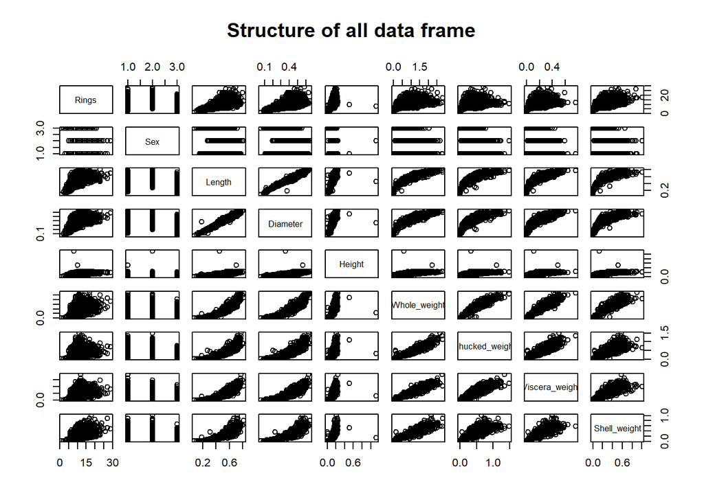

The graph reflects the relationship between each pair of variables of our data frame.

We can notice some critical outliers in this plot.

For example, two height observations are strongly out of the general model.

Vizualise some of the most critical outliers

### 2.1.2 Outliers

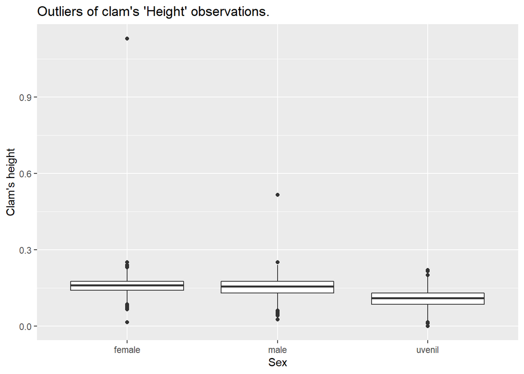

There are two points (observations) that deviate grately from the interquartile range.

In addition, there are a number of observations that are close to the interquartile range but not within it. These are also potential outliers.

Structure shows that the least amount of outliers are observed in “Diameter” variable.

Build another boxplot to represent how many observations are deviate from the interquartile range.

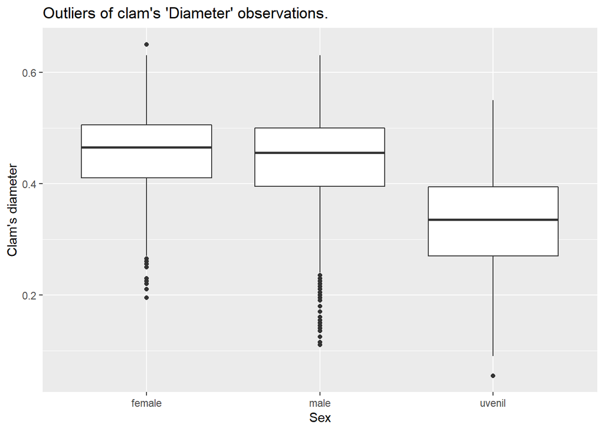

There are some outliers in Diameter observations which are marked on the graph with separate points and deviate from 1,5 * interquartile range.

Even in “Diameter” var.there are a lot of outliers. Worth to keep it in mind during analysis.

## 2.2 Сhecking the correctness of data

We have two types of variables.

- 1st - Rings & Sex - discrete variables
- 2nd - other vars which can be introduced as a float type or continuous variables

Let’s look at their quality separately.

### 2.2.1 Mistakes in discrete variables

Here is the subset of observations with mistakes in “Rings” and “Sex” vars.

```
##      Rings   Sex Length Diameter Height Whole_weight Shucked_weight
## 343     10  <NA>   0.58    0.475  0.155       0.9740         0.4305
## 618      8 three  0.425    0.325  0.110       0.4050         0.1695
## 1374     9   one   0.44    0.355  0.125       0.4775         0.1320
## 1399    11  male   0.58    0.470  0.165       0.9270         0.3215
## 3372  nine     3   0.55    0.400  0.135       0.7170         0.3315
##      Viscera_weight Shell_weight
## 343          0.2300       0.2850
## 618          0.0920       0.1065
## 1374         0.0815       0.1900
## 1399         0.1985       0.3150
## 3372         0.1495       0.2210
```

I believe that the best approach to correcting errors in this subset is follows:

We can’t reestablish missing observation of Sex because it’s factor variable, so let’s just remove this row. For others observations in this case we can fix mistakes manually. The solution is only suitable for this data, since there are few errors in it. Perhaps for other data of this structure it would be better to simply delete rows with erroneous values.

```
##      Rings Sex Length Diameter Height Whole_weight Shucked_weight
## 618      8   3  0.425    0.325  0.110       0.4050         0.1695
## 1374     9   1  0.440    0.355  0.125       0.4775         0.1320
## 1399    11   1  0.580    0.470  0.165       0.9270         0.3215
## 3372     9   3  0.550    0.400  0.135       0.7170         0.3315
##      Viscera_weight Shell_weight
## 618          0.0920       0.1065
## 1374         0.0815       0.1900
## 1399         0.1985       0.3150
## 3372         0.1495       0.2210
```

Here is a list of corrected rows.

### 2.2.2 Mistakes in continuous variables

Here is the subset of observations with mistakes in continuous vars.

```
##      Length Diameter Height Whole_weight Shucked_weight Viscera_weight
## 136      NA    0.385  0.110       0.5785         0.2530         0.1600
## 240   0.415       NA  0.110       0.3160         0.1385         0.0795
## 429   0.525       NA  0.120       0.6315         0.3045         0.1140
## 633   0.510       NA  0.135       0.6335         0.2310         0.1790
## 639   0.615    0.480  0.160       1.2525         0.5850         0.2595
## 1224     NA    0.325  0.100       0.3940         0.2080         0.0655
## 1290  0.240    0.175  0.055       0.0705             NA         0.0140
## 1490  0.170       NA  0.035       0.0340         0.0120         0.0085
## 1738     NA    0.440  0.175       0.7745         0.2985         0.1875
## 1769  0.670    0.535  0.190           NA         0.7465         0.2935
## 1835  0.670    0.525  0.165       1.6085         0.6820         0.3145
## 1878  0.440    0.340     NA       0.4195         0.1530         0.1155
## 1908     NA    0.435  0.175       0.9820         0.4055         0.2495
## 2678  0.410    0.300  0.100       0.3010             NA         0.0690
```

[output cut: 27 more lines]

The easiest way to deal with NAs is to remove them. Also we can replace them with mean or median (median is better as the dataset has a lot of outliers).

Also there are other ways to replace NAs. For example calculate missing values using k-nearest neighbours or bagging model but these methods take longer to execute.

Perhaps it’s worth not to remove NA observations and try to fill them for some variables.

According to the data structure I suppose that “Length” and “Diameter” are interrelated with each other. So I checked it with correlation test.

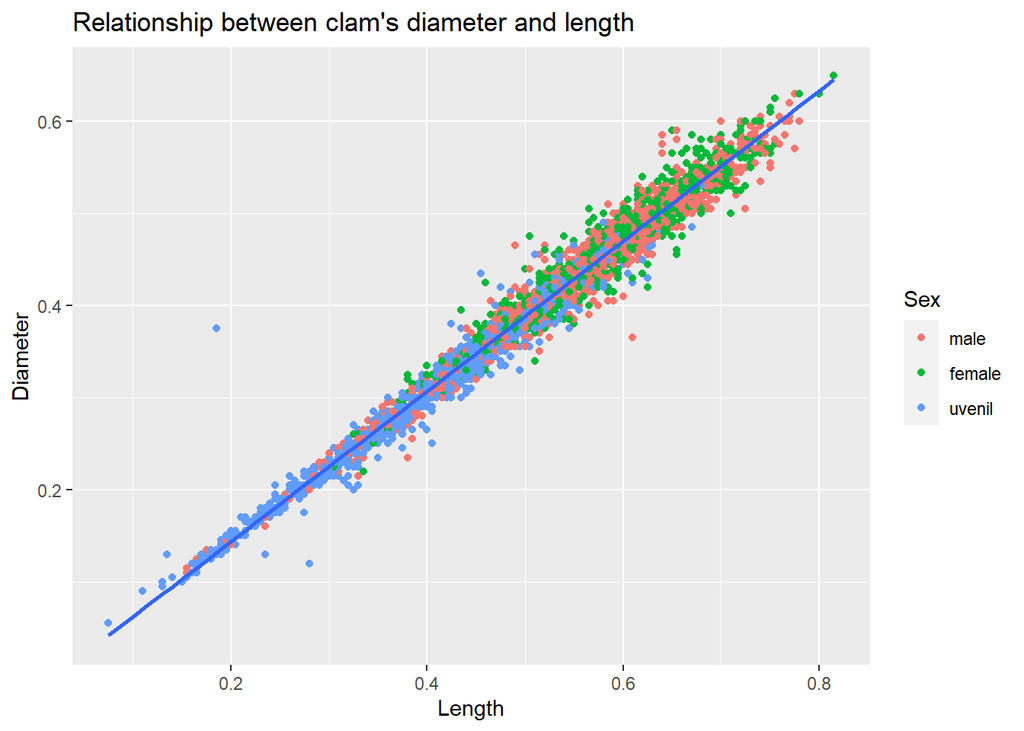

The graph shows the dependence of the diameter and length. As you can see, it is close to linear.

There is performing a correlation test for “Diameter” and “Length” above.

```
##
##  Pearson's product-moment correlation
##
## data:  working_df1$Length and working_df1$Diameter
## t = 393.12, df = 4163, p-value < 2.2e-16
## alternative hypothesis: true correlation is not equal to 0
## 95 percent confidence interval:
##  0.9859763 0.9875711
## sample estimates:
##       cor
## 0.9867976
```

For the rest of the variables, delete the missing values, since there are not many of them. In this case, we will definitely not introduce errors into the data. In addition, we remove outliers

## 2.3 Some hypotheses

From the structure, we can assume:

- Mussel length and diameter are related (most likely linearly).
- Length (or diameter) is interrelated with any weight variable (not linearly. If the average density of a mussel is always approximately the same, then its mass is proportional to the cube of length)
- Perhaps the number of rings is related to age and does not depend on gender.
- The number of rings is possibly related to the height of the mussel

# 3 Counting mean and standart deviation for Length

```
## # A tibble: 3 x 3
##   Sex_name  mean     sd
##   <chr>    <dbl>  <dbl>
## 1 female   0.579 0.0863
## 2 male     0.562 0.103
## 3 uvenil   0.428 0.109
```

# 4 Calms percent with height which is not greater than 0.165

Counted percent of calms with height not greater than 0.165 is 75.8860153

# 5 Scaling of the Length column

```
##    Length Length_z_scores
## 1   0.815        2.421606
## 2   0.770        2.047046
## 3   0.775        2.088664
## 4   0.800        2.296753
## 5   0.770        2.047046
## 6   0.765        2.005428
## 7   0.770        2.047046
## 8   0.780        2.130282
## 9   0.775        2.088664
## 10  0.780        2.130282
## 11  0.765        2.005428
```

Standart deviation of Length_z_scores is 1 and mean value is 2.159346610^{-16} which is highly equal to 0 as we expect.

# 6 The value of the Length, which is greater than 92% of all observations

The desired value is: 0.67

# 7 Clam’s diameter in two groups (with 5 and 15 rings)

We assume that the mean diameter in the two groups (with 5 and 15 rings) is significantly different. The Wilcoxon test was used to verify this.

We analyzed the distribution and homogeneity of variance in both groups. The graph shows that the distribution is close to normal

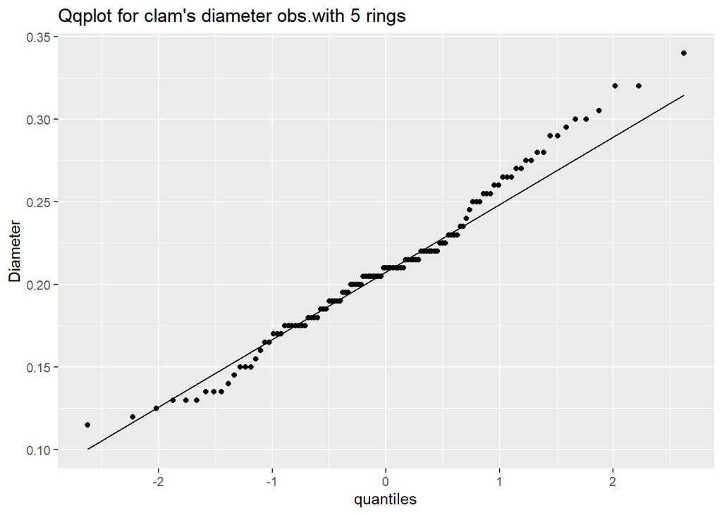

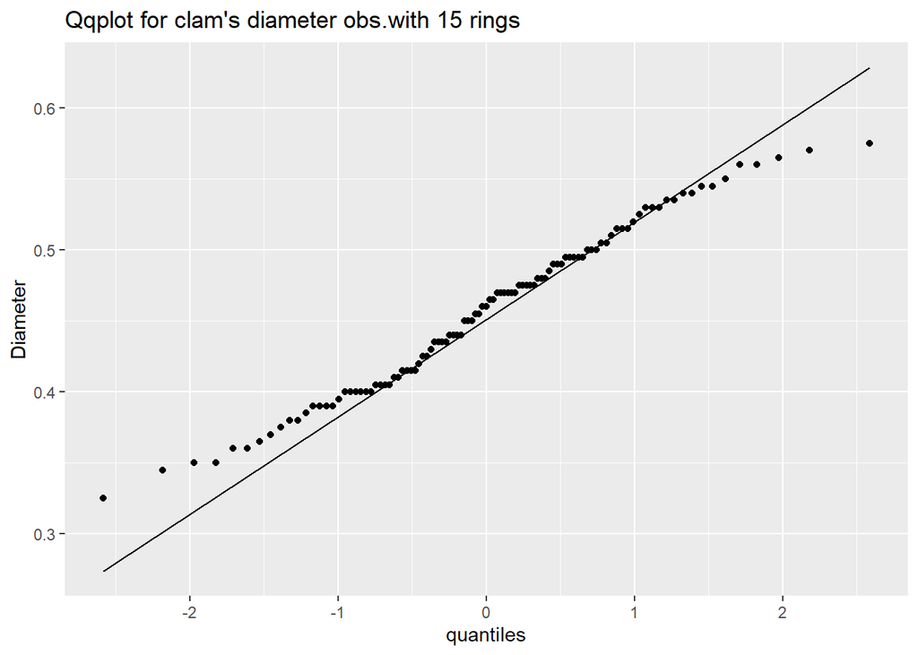

Line shows real normal distribution and points - real observations of diameter.

Shapiro-Wilk test showed that the distribution in both cases is close to normal too.

For group with 5 rings p-value of Shapiro-Wilk test is 0.1160922 more then 0.05. P-value of Shapiro-Wilk test for group with 15 rings is 0.1836328 more then 0.05. For both groups, the p-value is significantly greater than 0.05, which allows us to consider the distribution in both cases is normal.

Analysis of homogeneity of variance was carried out using the Bartlett test.

p-value is less then 0.05 (p-value = 0.0222398) so we conclude that homogeneity of dispersion is not observed within the two groups.

Despite the fact that in both groups the distribution is normal, the dispersions are inhomogeneous. So we use nonparametric Wilcoxon test to test the hypothesis of equality of two means.

P-value is much less than 0.05 (p-value = 3.666858210^{-37} ), we reject the null hypothesis of equality of two means.

Therefore, means in the two groups (with 5 and 15 rings) differ significantly.

# 8 Diameter versus total weight

We analyzed the relationship of two variables (diameter and total weight) and assumed that they are related.

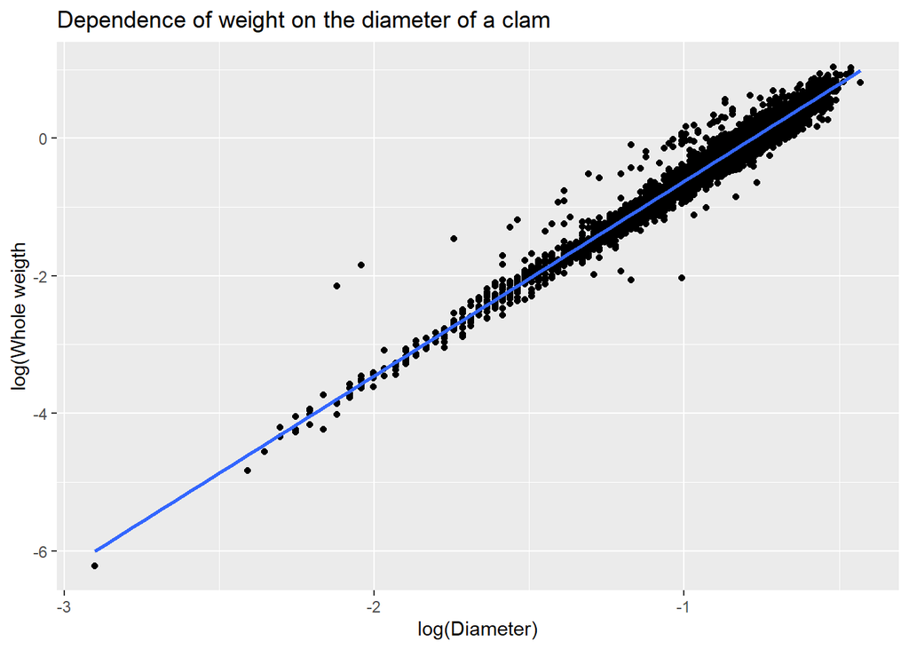

Almost all observations are close to their estimated values marked on the graph as a straight line.

It can be assumed from the graph that the relationship is power-law.

To determine the presence of a relationship between two variables, we used correlation analysis. To assess the correlation between diameter and total weight, the Kendall correlation coefficient was used since the distribution of variables differs from the normal with p-value 1.003043910^{-27} for Weigth and p-value 1.847269910^{-28} for Diameter.

The correlation between the variables is 0.8736446 p-value is 0. There is a positive linear relationship between the logarithmic variables.

In addition, it is interesting to see how exactly these variables are interrelated.

It is obvious that for variables of diameter and total weight, a power dependence is observed.Since m = ρ*V and volume is proportional to linear dimension to the third degree. It can be assumed that the diameter is in the third power proportional to the total weight. However, it should be noted that the weight of the shell makes some adjustments to this assumption. Since the thickness of the shell does not change much with increasing size, it can be assumed that only the surface area of the shell is important for calculating the weigth. Then the diameter squared is proportional to the weigth, and accordingly, the total weigth will be proportional to the diameter to a degree somewhat less than 3.

Drawing up a regression equation for logarithmic values gave the following result.

The final equation is log(Whole weigth) = 2.1990978 + 2.8269742*log(Diameter)

As we suppose total weigth is proportional to the diameter in 2.8269742 degree (which is a little less then 3)

# 9 Differences in size depending on the number of rings

Let’s check the hypothesis that the number of rings depends on age.

Mean clam’s number of rings for uvenils is 7.890462 and mean for adults is 10.9011997.

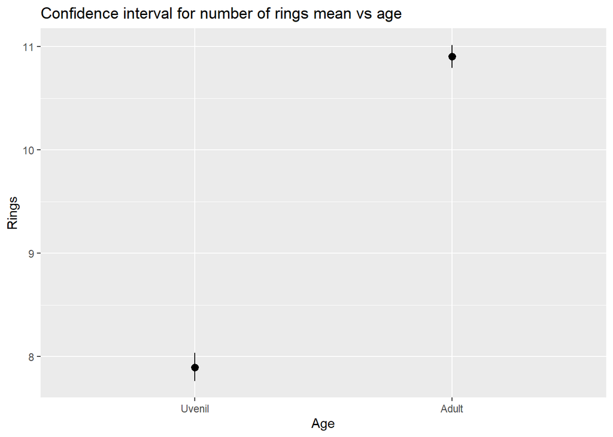

Since the average number of rings for uvenils does not fall within the confidence interval for the average number of rings in adults and vice versa, the confidence interval for the average number of rings in adults does not fall within the confidence interval for the average number of rings in uvenils, we conclude that the differences are statistically significant. This means that the number of rings really depends on age